# Modeling and prediction for movies

## Setup

### Load packages

```r
library(ggplot2)
library(dplyr)
library(statsr)
library(gridExtra)
library(corrplot)
library("Hmisc")
library(tidyverse)
```

### Load data

```r
load("movies.Rdata")
```

## Part 1: Data

The data set is comprised of 651 randomly sampled movies produced and released before 2016, including information from the widely acclaimed websites IMDB and Rotten Tomatoes. Studies based on this sample are: generalizable to the movie released before the year 2016 and not causal because there is no random assignment used in the sample collection.

The provided dataset contains information about the title of a movie, genre, runtime, studio, release, critics rating, director, and other 25 more variables. * * *

## Part 2: Research question

This study aims to determine how the movie’s popularity is measured, by using variables in the dataset as an audience score, related to the genre of movie, its runtime, IMDb rating, number of votes, critics rating, score, audience rating, oscar awards won (actor, actress, director, and picture)? The fact that we can answer this question will help us predict the popularity of a movie. * * *

## Part 3: Exploratory data analysis

Summary of data from the above-mentioned potential predictors for the model.

```r
model_movies <- movies %>% select(title, title_type, genre, runtime, imdb_rating, imdb_num_votes, critics_rating, critics_score, audience_rating, audience_score, best_pic_win, best_actor_win, best_actress_win, best_dir_win)
```

Examine the structure of data.

```r
str(model_movies)
```

```
## tibble [651 x 14] (S3: tbl_df/tbl/data.frame)
##  $ title           : chr [1:651] "Filly Brown" "The Dish" "Waiting for Guffman" "The Age of Innocence" ...
##  $ title_type      : Factor w/ 3 levels "Documentary",..: 2 2 2 2 2 1 2 2 1 2 ...
##  $ genre           : Factor w/ 11 levels "Action & Adventure",..: 6 6 4 6 7 5 6 6 5 6 ...
##  $ runtime         : num [1:651] 80 101 84 139 90 78 142 93 88 119 ...
##  $ imdb_rating     : num [1:651] 5.5 7.3 7.6 7.2 5.1 7.8 7.2 5.5 7.5 6.6 ...
##  $ imdb_num_votes  : int [1:651] 899 12285 22381 35096 2386 333 5016 2272 880 12496 ...
##  $ critics_rating  : Factor w/ 3 levels "Certified Fresh",..: 3 1 1 1 3 2 3 3 2 1 ...
##  $ critics_score   : num [1:651] 45 96 91 80 33 91 57 17 90 83 ...
##  $ audience_rating : Factor w/ 2 levels "Spilled","Upright": 2 2 2 2 1 2 2 1 2 2 ...
##  $ audience_score  : num [1:651] 73 81 91 76 27 86 76 47 89 66 ...
##  $ best_pic_win    : Factor w/ 2 levels "no","yes": 1 1 1 1 1 1 1 1 1 1 ...
##  $ best_actor_win  : Factor w/ 2 levels "no","yes": 1 1 1 2 1 1 1 2 1 1 ...
##  $ best_actress_win: Factor w/ 2 levels "no","yes": 1 1 1 1 1 1 1 1 1 1 ...
##  $ best_dir_win    : Factor w/ 2 levels "no","yes": 1 1 1 2 1 1 1 1 1 1 ...
```

**Summary statistics**

```r
summary(model_movies)
```

```
##     title                  title_type                 genre        runtime
##  Length:651         Documentary : 55   Drama             :305   Min.   : 39.0
##  Class :character   Feature Film:591   Comedy            : 87   1st Qu.: 92.0
##  Mode  :character   TV Movie    :  5   Action & Adventure: 65   Median :103.0
##                                        Mystery & Suspense: 59   Mean   :105.8
##                                        Documentary       : 52   3rd Qu.:115.8
##                                        Horror            : 23   Max.   :267.0
##                                        (Other)           : 60   NA's   :1
##   imdb_rating    imdb_num_votes           critics_rating critics_score
##  Min.   :1.900   Min.   :   180   Certified Fresh:135    Min.   :  1.00
##  1st Qu.:5.900   1st Qu.:  4546   Fresh          :209    1st Qu.: 33.00
##  Median :6.600   Median : 15116   Rotten         :307    Median : 61.00
##  Mean   :6.493   Mean   : 57533                          Mean   : 57.69
##  3rd Qu.:7.300   3rd Qu.: 58301                          3rd Qu.: 83.00
##  Max.   :9.000   Max.   :893008                          Max.   :100.00
##
##  audience_rating audience_score  best_pic_win best_actor_win best_actress_win
##  Spilled:275     Min.   :11.00   no :644      no :558        no :579
##  Upright:376     1st Qu.:46.00   yes:  7      yes: 93        yes: 72
##                  Median :65.00
##                  Mean   :62.36
##                  3rd Qu.:80.00
##                  Max.   :97.00
##
##  best_dir_win
##  no :608
##  yes: 43
##
##
##
##
##
```

Removing NA’s if there any.

```r
model_movies <- na.omit(model_movies)
```

Part of the project is to use the model to predict the audience score of a film and that film should not be included in the data. So I’ve split the data into training and testing, and there’s only one line in the test set.

```r
set.seed(2017)
split <- sample(seq_len(nrow(model_movies)), size = floor(0.999 * nrow(model_movies)))
train <- model_movies[split, ]
test <- model_movies[-split, ]
dim(train)
```

```
## [1] 649  14
```

```r
dim(test)
```

```
## [1]  1 14
```

**Plotting Histograms of Numerical Variables and obtaining their summary**

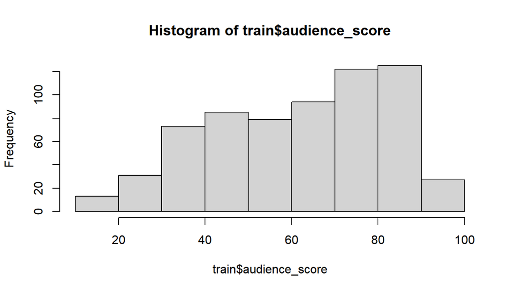

```r
hist(train$audience_score)
```

```r
summary(train$audience_score)
```

```
##    Min. 1st Qu.  Median    Mean 3rd Qu.    Max.
##   11.00   46.00   65.00   62.32   80.00   97.00
```

Our response variable ‘audience score’ has a median of 65, that is. 25% of the movie in the training set have an audience score higher than 80 and 25% of the movie in the training set have an audience score lower than 46. Very few movies have an audience score under 20 or above 90 (i.e. the audience in the data is unlikely to give a very low or very high score).

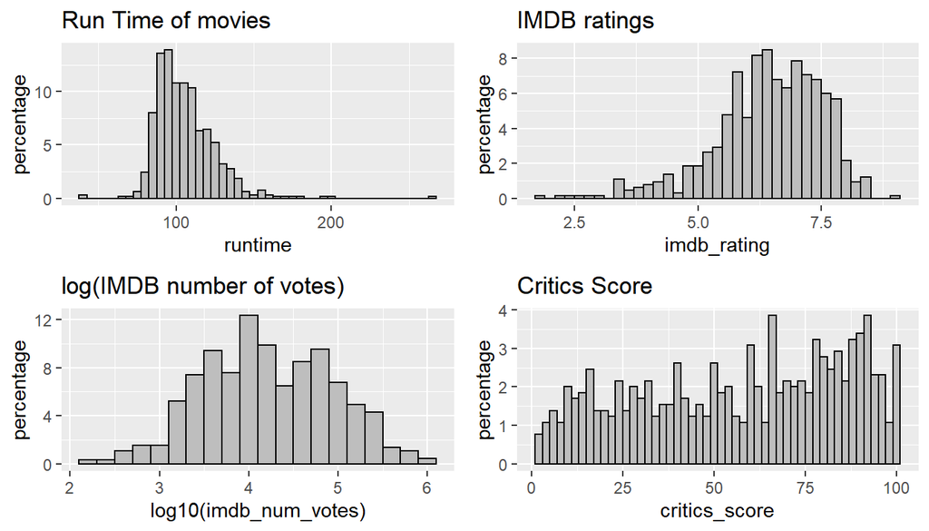

```r
plot1 <- ggplot(aes(x=runtime), data=train) +
  geom_histogram(aes(y=100*(..count..)/sum(..count..)), color='black', fill = 'grey', binwidth = 5) + ylab('percentage') + ggtitle('Run Time of movies')

plot2 <- ggplot(aes(x=imdb_rating), data=train) +
  geom_histogram(aes(y=100*(..count..)/sum(..count..)), color='black', fill = 'grey', binwidth = 0.2) + ylab('percentage') + ggtitle('IMDB ratings')

plot3 <- ggplot(aes(x=log10(imdb_num_votes)), data=train) +
  geom_histogram(aes(y=100*(..count..)/sum(..count..)), color='black', fill = 'grey', binwidth = 0.2) +  ylab('percentage') + ggtitle('log(IMDB number of votes)')

plot4 <- ggplot(aes(x=critics_score), data=train) +
  geom_histogram(aes(y=100*(..count..)/sum(..count..)), color='black', fill = 'grey', binwidth = 2) + ylab('percentage') + ggtitle('Critics Score')

grid.arrange(plot1, plot2, plot3, plot4, ncol=2)
```

Regression analysis: Movies run time, IMDB ratings, log (IMDB number of votes), and critical scores all have a wide reasonable distribution, so they will be considered for regression analysis.

**Plotting Bar plot of categorical variables.**

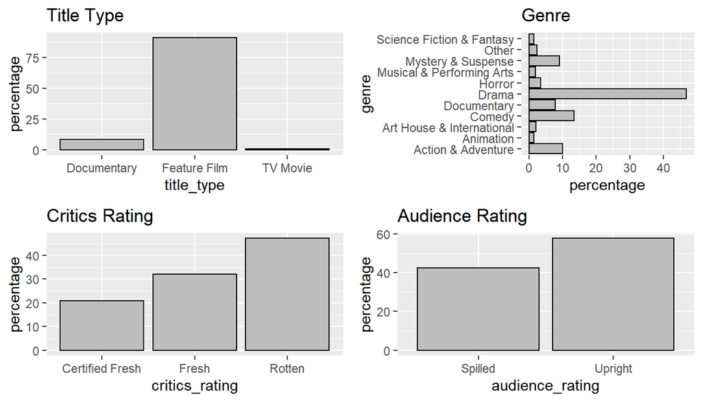

```r
plot5 <- ggplot(aes(x=title_type), data=train) + geom_bar(aes(y=100*(..count..)/sum(..count..)), color='black', fill = 'grey') + ylab('percentage') +  ggtitle('Title Type')

plot6 <- ggplot(aes(x=genre), data=train) + geom_bar(aes(y=100*(..count..)/sum(..count..)), color='black', fill = 'grey') + ylab('percentage') +  ggtitle('Genre') + coord_flip()

plot7 <- ggplot(aes(x=critics_rating), data=train) + geom_bar(aes(y=100*(..count..)/sum(..count..)), color='black', fill = 'grey') + ylab('percentage') +  ggtitle('Critics Rating')

plot8 <- ggplot(aes(x=audience_rating), data=train) + geom_bar(aes(y=100*(..count..)/sum(..count..)), color='black', fill = 'grey') + ylab('percentage') +  ggtitle('Audience Rating')

grid.arrange(plot5, plot6, plot7, plot8, ncol=2)
```

All of these categorical variables are not reasonably distributed. Most of the movies in the data are “Feature Film” and most of the films are having a genre as drama. As a result, we must be aware that the results could be biased in a favour of dramatic movies.

**Correlation between numerical variables**

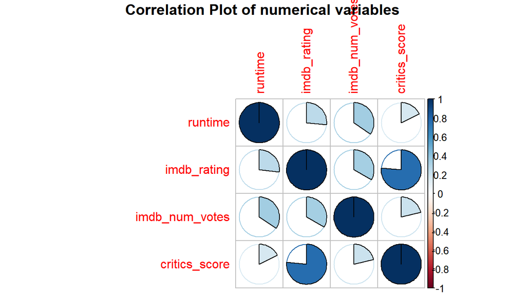

```r
vars <- names(train) %in% c('runtime', 'imdb_rating', 'imdb_num_votes', 'critics_score')
selected_train <- train[vars]

corr.matrix <- cor(selected_train)
corrplot(corr.matrix, method="pie", main ="\nCorrelation Plot of numerical variables")
```

Two predictors - critics_score and imdb_rating are strongly correlated with more than 75% (collinearity), so, one will be removed from the model, I decided to remove the critics_score.

**Correlation between categorical variables and audience score**

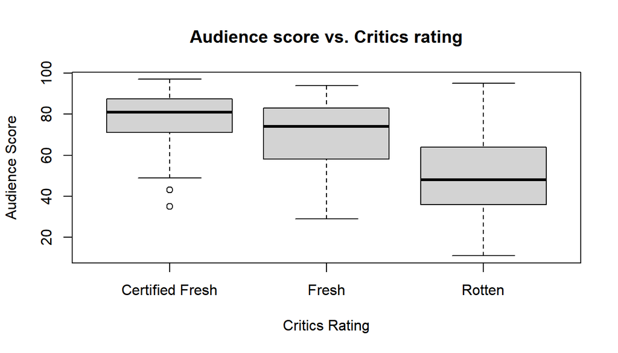

```r
plot9 <- boxplot(audience_score~critics_rating, data=train, main='Audience score vs. Critics rating', xlab='Critics Rating', ylab='Audience Score')
```

```r
by(train$audience_score, train$critics_rating, summary)
```

```
## train$critics_rating: Certified Fresh
##    Min. 1st Qu.  Median    Mean 3rd Qu.    Max.
##   35.00   71.00   81.00   79.37   87.50   97.00
## ------------------------------------------------------------
## train$critics_rating: Fresh
##    Min. 1st Qu.  Median    Mean 3rd Qu.    Max.
##   29.00   58.00   74.00   69.96   83.00   94.00
## ------------------------------------------------------------
## train$critics_rating: Rotten
##    Min. 1st Qu.  Median    Mean 3rd Qu.    Max.
##   11.00   36.00   48.00   49.60   63.75   95.00
```

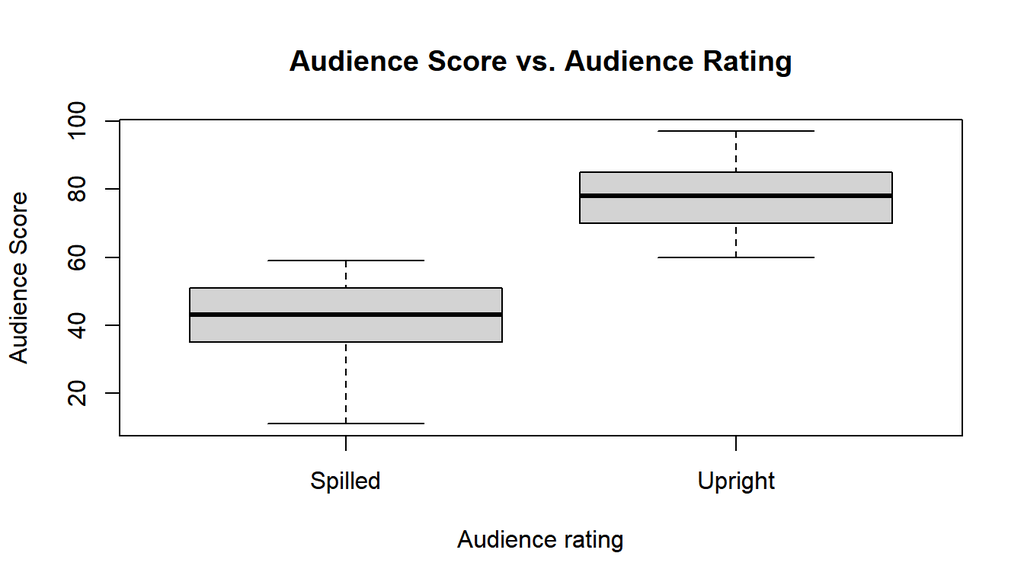

```r
plot10 <- boxplot(audience_score~audience_rating, data=train, main='Audience Score vs. Audience Rating', xlab='Audience rating', ylab='Audience Score')
```

```r
by(train$audience_score, train$audience_rating, summary)
```

```
## train$audience_rating: Spilled
##    Min. 1st Qu.  Median    Mean 3rd Qu.    Max.
##   11.00   35.00   43.00   41.93   51.00   59.00
## ------------------------------------------------------------
## train$audience_rating: Upright
##    Min. 1st Qu.  Median    Mean 3rd Qu.    Max.
##   60.00   70.00   78.00   77.31   85.00   97.00
```

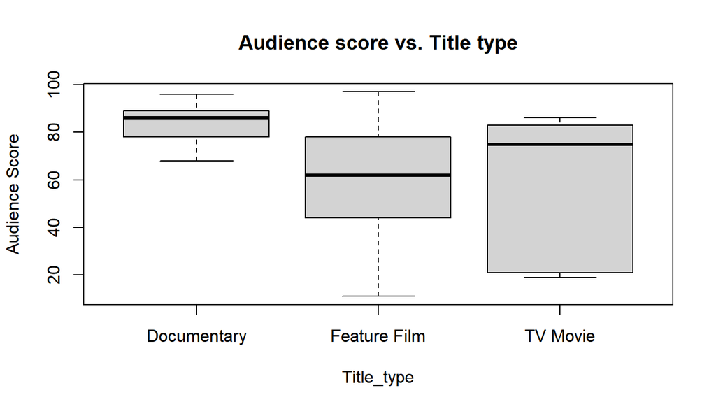

```r
plot11 <- boxplot(audience_score~title_type, data=train, main='Audience score vs. Title type', xlab='Title_type', ylab='Audience Score')
```

```r
by(train$audience_score, train$title_type, summary)
```

```
## train$title_type: Documentary
##    Min. 1st Qu.  Median    Mean 3rd Qu.    Max.
##   68.00   78.00   86.00   83.46   89.00   96.00
## ------------------------------------------------------------
## train$title_type: Feature Film
##    Min. 1st Qu.  Median    Mean 3rd Qu.    Max.
##   11.00   44.25   62.00   60.43   78.00   97.00
## ------------------------------------------------------------
## train$title_type: TV Movie
##    Min. 1st Qu.  Median    Mean 3rd Qu.    Max.
##    19.0    21.0    75.0    56.8    83.0    86.0
```

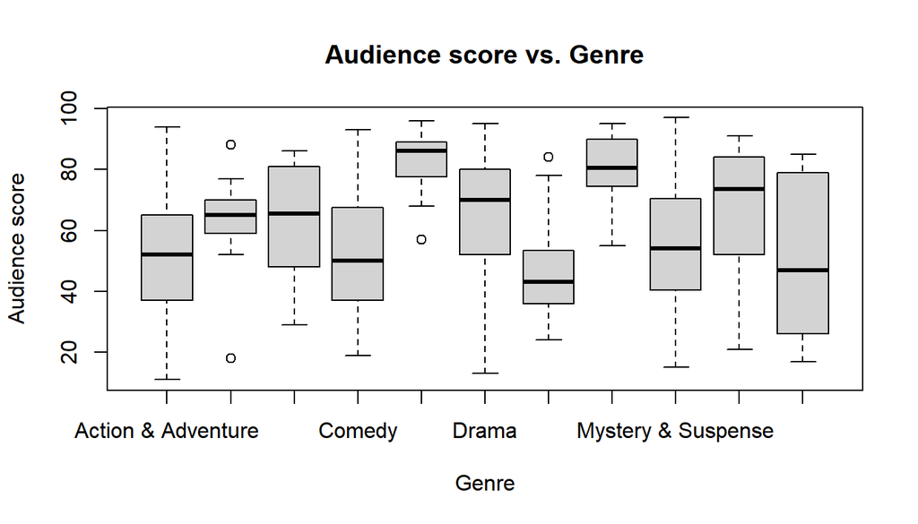

```r
plot12 <- boxplot(audience_score~genre, data=train, main='Audience score vs. Genre', xlab='Genre', ylab='Audience score')
```

```r
by(train$audience_score, train$genre, summary)
```

```
## train$genre: Action & Adventure
##    Min. 1st Qu.  Median    Mean 3rd Qu.    Max.
##   11.00   37.00   52.00   53.78   65.00   94.00
## ------------------------------------------------------------
## train$genre: Animation
##    Min. 1st Qu.  Median    Mean 3rd Qu.    Max.
##   18.00   59.00   65.00   62.44   70.00   88.00
## ------------------------------------------------------------
## train$genre: Art House & International
##    Min. 1st Qu.  Median    Mean 3rd Qu.    Max.
##   29.00   51.25   65.50   64.00   80.25   86.00
## ------------------------------------------------------------
## train$genre: Comedy
##    Min. 1st Qu.  Median    Mean 3rd Qu.    Max.
##   19.00   37.00   50.00   52.51   67.50   93.00
## ------------------------------------------------------------
## train$genre: Documentary
##    Min. 1st Qu.  Median    Mean 3rd Qu.    Max.
##   57.00   77.50   86.00   82.96   89.00   96.00
## ------------------------------------------------------------
## train$genre: Drama
##    Min. 1st Qu.  Median    Mean 3rd Qu.    Max.
##    13.0    52.0    70.0    65.3    80.0    95.0
## ------------------------------------------------------------
## train$genre: Horror
##    Min. 1st Qu.  Median    Mean 3rd Qu.    Max.
##   24.00   36.00   43.00   45.83   53.50   84.00
## ------------------------------------------------------------
## train$genre: Musical & Performing Arts
##    Min. 1st Qu.  Median    Mean 3rd Qu.    Max.
##   55.00   75.75   80.50   80.17   89.50   95.00
## ------------------------------------------------------------
## train$genre: Mystery & Suspense
##    Min. 1st Qu.  Median    Mean 3rd Qu.    Max.
##   15.00   40.50   54.00   55.95   70.50   97.00
## ------------------------------------------------------------
## train$genre: Other
##    Min. 1st Qu.  Median    Mean 3rd Qu.    Max.
##   21.00   53.00   73.50   66.69   82.50   91.00
## ------------------------------------------------------------
## train$genre: Science Fiction & Fantasy
##    Min. 1st Qu.  Median    Mean 3rd Qu.    Max.
##   17.00   26.00   47.00   50.89   79.00   85.00
```

All categorical variables appear to correlate reasonably significantly with the audience score.

## Part 4: Modeling

We will use the stepwise model forward selection method and start with an empty model, then add variables one at a time until a parsimonious model is reached.

```r
full_model_movies <- lm(audience_score~imdb_rating + title_type + genre + runtime + imdb_num_votes + critics_rating + audience_rating + best_pic_win + best_actor_win + best_actress_win + best_dir_win, data=train)

summary(full_model_movies)
```

```
##
## Call:
## lm(formula = audience_score ~ imdb_rating + title_type + genre +
##     runtime + imdb_num_votes + critics_rating + audience_rating +
##     best_pic_win + best_actor_win + best_actress_win + best_dir_win,
##     data = train)
##
## Residuals:
##      Min       1Q   Median       3Q      Max
## -21.5184  -4.4880   0.5766   4.3247  24.5522
##
## Coefficients:
##                                  Estimate Std. Error t value Pr(>|t|)
## (Intercept)                    -9.713e+00  4.061e+00  -2.392   0.0171 *
## imdb_rating                     9.558e+00  4.284e-01  22.312   <2e-16 ***
## title_typeFeature Film          2.232e+00  2.542e+00   0.878   0.3804
## title_typeTV Movie              6.893e-01  4.029e+00   0.171   0.8642
## genreAnimation                  3.184e+00  2.476e+00   1.286   0.1988
## genreArt House & International -2.583e+00  2.060e+00  -1.254   0.2103
## genreComedy                     1.497e+00  1.142e+00   1.311   0.1904
## genreDocumentary                2.477e+00  2.722e+00   0.910   0.3631
## genreDrama                     -6.352e-01  9.915e-01  -0.641   0.5220
## genreHorror                    -1.927e+00  1.686e+00  -1.143   0.2534
## genreMusical & Performing Arts  3.570e+00  2.357e+00   1.515   0.1304
## genreMystery & Suspense        -3.162e+00  1.268e+00  -2.494   0.0129 *
## genreOther                      2.711e-01  1.951e+00   0.139   0.8895
## genreScience Fiction & Fantasy -2.615e-01  2.458e+00  -0.106   0.9153
## runtime                        -2.732e-02  1.679e-02  -1.628   0.1041
## imdb_num_votes                  2.837e-06  3.079e-06   0.921   0.3572
## critics_ratingFresh            -1.029e-02  8.423e-01  -0.012   0.9903
## critics_ratingRotten           -1.262e+00  9.318e-01  -1.354   0.1763
## audience_ratingUpright          2.005e+01  7.908e-01  25.350   <2e-16 ***
## best_pic_winyes                 4.731e-01  2.917e+00   0.162   0.8712
## best_actor_winyes               1.991e-01  8.140e-01   0.245   0.8069
## best_actress_winyes            -9.973e-01  9.026e-01  -1.105   0.2696
## best_dir_winyes                 1.841e-01  1.187e+00   0.155   0.8768
## ---
## Signif. codes:  0 '***' 0.001 '**' 0.01 '*' 0.05 '.' 0.1 ' ' 1
##
## Residual standard error: 6.867 on 626 degrees of freedom
## Multiple R-squared:  0.8888, Adjusted R-squared:  0.8849
## F-statistic: 227.4 on 22 and 626 DF,  p-value: < 2.2e-16
```

```r
model1 <- lm(audience_score ~ imdb_rating, data=train)
summary(model1)
```

```
##
## Call:
## lm(formula = audience_score ~ imdb_rating, data = train)
##
## Residuals:
##     Min      1Q  Median      3Q     Max
## -26.795  -6.533   0.655   5.692  52.905
##
## Coefficients:
##             Estimate Std. Error t value Pr(>|t|)
## (Intercept) -42.3426     2.4212  -17.49   <2e-16 ***
## imdb_rating  16.1251     0.3679   43.83   <2e-16 ***
## ---
## Signif. codes:  0 '***' 0.001 '**' 0.01 '*' 0.05 '.' 0.1 ' ' 1
##
## Residual standard error: 10.17 on 647 degrees of freedom
## Multiple R-squared:  0.748,  Adjusted R-squared:  0.7476
## F-statistic:  1921 on 1 and 647 DF,  p-value: < 2.2e-16
```

The 0.748 R-squared and almost zero p-values indicate that imdb_rating is a statistically significant predictor of audience score.

To find out the second predictor, I look at the following model.

```r
model2 <- lm(audience_score~title_type + genre + runtime + imdb_num_votes + critics_rating + audience_rating + best_pic_win + best_actor_win + best_actress_win + best_dir_win, data=train)

summary(model2)
```

```
##
## Call:
## lm(formula = audience_score ~ title_type + genre + runtime +
##     imdb_num_votes + critics_rating + audience_rating + best_pic_win +
##     best_actor_win + best_actress_win + best_dir_win, data = train)
##
## Residuals:
##      Min       1Q   Median       3Q      Max
## -30.4370  -6.0200   0.8101   6.5995  19.2891
##
## Coefficients:
##                                  Estimate Std. Error t value Pr(>|t|)
## (Intercept)                     4.511e+01  4.329e+00  10.420  < 2e-16 ***
## title_typeFeature Film         -8.178e-01  3.399e+00  -0.241   0.8099
## title_typeTV Movie             -6.012e+00  5.379e+00  -1.118   0.2641
## genreAnimation                  6.284e-02  3.309e+00   0.019   0.9849
## genreArt House & International  5.425e-01  2.752e+00   0.197   0.8438
## genreComedy                     3.189e-01  1.527e+00   0.209   0.8347
## genreDocumentary                8.062e+00  3.629e+00   2.222   0.0267 *
## genreDrama                      1.611e+00  1.321e+00   1.220   0.2230
## genreHorror                    -8.176e-01  2.256e+00  -0.362   0.7171
## genreMusical & Performing Arts  8.031e+00  3.144e+00   2.554   0.0109 *
## genreMystery & Suspense        -4.128e-01  1.689e+00  -0.244   0.8070
## genreOther                      5.464e-01  2.612e+00   0.209   0.8343
## genreScience Fiction & Fantasy -3.521e+00  3.285e+00  -1.072   0.2843
## runtime                         2.100e-02  2.228e-02   0.942   0.3464
## imdb_num_votes                  1.833e-05  4.016e-06   4.563 6.06e-06 ***
## critics_ratingFresh            -4.235e-01  1.127e+00  -0.376   0.7073
## critics_ratingRotten           -7.308e+00  1.194e+00  -6.123 1.62e-09 ***
## audience_ratingUpright          2.894e+01  9.142e-01  31.663  < 2e-16 ***
## best_pic_winyes                -1.183e+00  3.905e+00  -0.303   0.7620
## best_actor_winyes               8.012e-01  1.089e+00   0.736   0.4623
## best_actress_winyes            -5.554e-01  1.208e+00  -0.460   0.6459
## best_dir_winyes                 1.498e+00  1.587e+00   0.944   0.3456
## ---
## Signif. codes:  0 '***' 0.001 '**' 0.01 '*' 0.05 '.' 0.1 ' ' 1
##
## Residual standard error: 9.193 on 627 degrees of freedom
## Multiple R-squared:  0.8003, Adjusted R-squared:  0.7936
## F-statistic: 119.7 on 21 and 627 DF,  p-value: < 2.2e-16
```

We add audience_rating as the second predictor because of the lowest p value.

```r
model3 <- lm(audience_score ~ imdb_rating + audience_rating, data=train)

summary(model3)
```

```
##
## Call:
## lm(formula = audience_score ~ imdb_rating + audience_rating,
##     data = train)
##
## Residuals:
##      Min       1Q   Median       3Q      Max
## -22.1510  -4.7695   0.6162   4.3688  24.3404
##
## Coefficients:
##                        Estimate Std. Error t value Pr(>|t|)
## (Intercept)            -11.5337     2.0073  -5.746 1.41e-08 ***
## imdb_rating              9.5275     0.3498  27.238  < 2e-16 ***
## audience_ratingUpright  20.8470     0.7677  27.154  < 2e-16 ***
## ---
## Signif. codes:  0 '***' 0.001 '**' 0.01 '*' 0.05 '.' 0.1 ' ' 1
##
## Residual standard error: 6.953 on 646 degrees of freedom
## Multiple R-squared:  0.8823, Adjusted R-squared:  0.882
## F-statistic:  2422 on 2 and 646 DF,  p-value: < 2.2e-16
```

The models we have run so far, R-squared and Adjusted R-Squared both increased significantly, the almost zero p-values indicate that audience_rating is another statistically significant predictor of audience_score.

```r
model4 <- lm(audience_score ~ imdb_rating + audience_rating + genre, data=train)

anova(model4)
```

```
## Analysis of Variance Table
##
## Response: audience_score
##                  Df Sum Sq Mean Sq   F value    Pr(>F)
## imdb_rating       1 198512  198512 4214.4653 < 2.2e-16 ***
## audience_rating   1  35641   35641  756.6690 < 2.2e-16 ***
## genre            10   1269     127    2.6938  0.003069 **
## Residuals       636  29957      47
## ---
## Signif. codes:  0 '***' 0.001 '**' 0.01 '*' 0.05 '.' 0.1 ' ' 1
```

Hence, I decide to add genre as one of the predictors. So, I arrived at our final model - Parsimonious Model, with three predictors as imdb_rating, audience_rating, and genre.

```r
summary(model4)
```

```
##
## Call:
## lm(formula = audience_score ~ imdb_rating + audience_rating +
##     genre, data = train)
##
## Residuals:
##      Min       1Q   Median       3Q      Max
## -21.6319  -4.4264   0.5933   4.2973  25.0928
##
## Coefficients:
##                                Estimate Std. Error t value Pr(>|t|)
## (Intercept)                    -12.5588     2.1965  -5.718 1.66e-08 ***
## imdb_rating                      9.8033     0.3691  26.560  < 2e-16 ***
## audience_ratingUpright          20.3058     0.7752  26.195  < 2e-16 ***
## genreAnimation                   3.6263     2.4524   1.479  0.13971
## genreArt House & International  -2.7874     2.0329  -1.371  0.17081
## genreComedy                      1.5106     1.1275   1.340  0.18077
## genreDocumentary                 0.6068     1.3702   0.443  0.65805
## genreDrama                      -0.8457     0.9595  -0.881  0.37843
## genreHorror                     -1.6223     1.6700  -0.971  0.33170
## genreMusical & Performing Arts   2.5474     2.1909   1.163  0.24539
## genreMystery & Suspense         -3.2744     1.2468  -2.626  0.00884 **
## genreOther                       0.2776     1.9260   0.144  0.88542
## genreScience Fiction & Fantasy   0.2554     2.4417   0.105  0.91672
## ---
## Signif. codes:  0 '***' 0.001 '**' 0.01 '*' 0.05 '.' 0.1 ' ' 1
##
## Residual standard error: 6.863 on 636 degrees of freedom
## Multiple R-squared:  0.8871, Adjusted R-squared:  0.885
## F-statistic: 416.5 on 12 and 636 DF,  p-value: < 2.2e-16
```

2. Intercept(-12.5588) is the estimated audience score for a movie with imdb_rating, audience_rating and genre at zero. It does not provide any meaningful interpretation here.
3. imdb_rating coefficient(9.8033): All else hold constant, for every one unit increase in imdb_rating, the model predicts a 9.8033 increase in audience_score on average.
4. genreMystery & Suspense coefficient(-3.2744): The model predicts that genreMystery & Suspense films get an audience score that is 3.2744 lower than Action & Adventure films on average after controlling for imdb_rating and audience rating.
5. audience_ratingUpright coefficient(20.3058): All else hold constant, the model predicts rating Upright movie is 20.3058 higher in audience score on average than rating Spilled movie.
6. genreAnimation coefficient(3.6263): The model predicts that Animation films get an audience score that is 3.6263 higher than Action & Adventure(reference category) films on average after controlling for imdb_rating and audience rating.
7. The total 11 genre categories in the dataset, the audience score can be higher or lower than Action & Adventure films depends on what genre is selected.

**Model diagnostics**

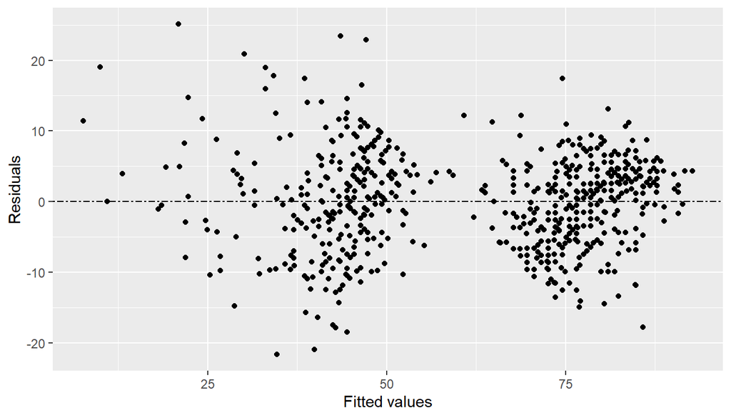

```r
ggplot(data = model4, aes(x = .fitted, y = .resid)) +
  geom_point() + geom_hline(yintercept = 0, linetype = "twodash") +
  xlab("Fitted values") +
  ylab("Residuals")
```

There is a linear relationship between imdb_rating and audience_score, thus the linearity condition is met by our model. The constant variance of residuals condition is met and no fan shape is shown in the residuals plot.

**Plotting Histogram and Normal distribution graph for further confirmation**

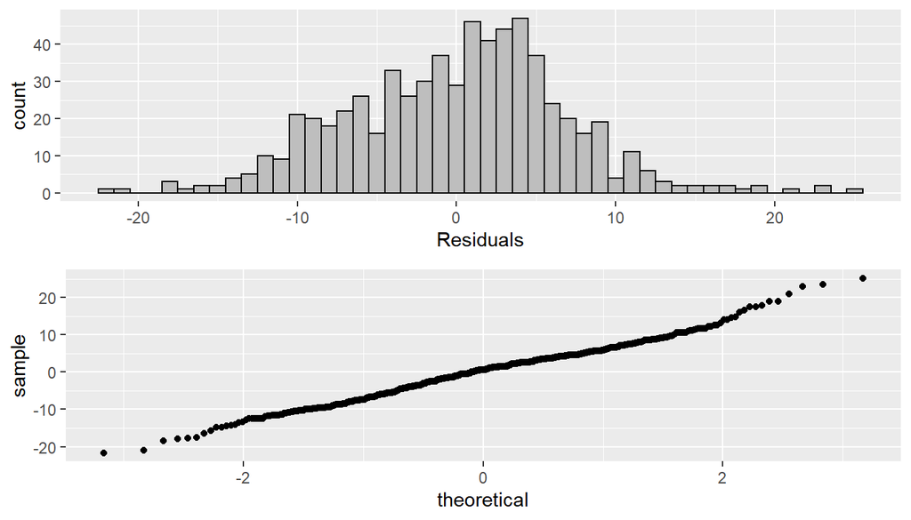

```r
plot13 <- ggplot(data = model4, aes(x = .resid)) +
  geom_histogram(binwidth = 1, fill='grey', color='black') +
  xlab("Residuals")

plot14 <- ggplot(data = model4, aes(sample = .resid)) +
  stat_qq()

grid.arrange(plot13, plot14, nrow=2)
```

## Part 5: Prediction

Now we try to use the model created earlier as model4 to predict the audience_score for the movie from the data set of movies that we have.

For such we need to create a new dataframe.

```r
imdb_rating<-7.7
genre <- "Drama"
critics_rating <-"Certified Fresh"
audience_score= 83
audience_rating<- "Upright"

predictmovie <- test %>% select(genre, imdb_rating, audience_rating)
predict(model4, predictmovie)
```

```
##        1
## 76.50501
```

```r
predict(model4, predictmovie, interval = "prediction", level = 0.95)
```

```
##        fit      lwr      upr
## 1 76.50501 62.99971 90.01032
```

```r
test$audience_score
```

```
## [1] 81
```

## Part 6: Conclusion

This model demonstrates that it is possible to predict a movie’s popularity using only three predictors - imdb score, audience rating and genre.

Movie industries can use the similar methods when producing movies that are more likely to be liked by the target audience furthermore this is just an assumption of my own that preety much fit with the real world.

Although, the potential shortcoming to this model’s predictive power is limited because the sample data is not representative and therefore, a larger number of observations to capture more variability in the population data in our testing data set is required to obtain a better measure of the model’s accuracy.